# Practical Machine Learning Course Project

Diana Nario

February 15, 2016

## Background

Using devices such as Jawbone Up, Nike FuelBand, and Fitbit it is now possible to collect a large amount of data about personal activity relatively inexpensively. These type of devices are part of the quantified self movement – a group of enthusiasts who take measurements about themselves regularly to improve their health, to find patterns in their behavior, or because they are tech geeks. One thing that people regularly do is quantify how much of a particular activity they do, but they rarely quantify how well they do it. In this project, your goal will be to use data from accelerometers on the belt, forearm, arm, and dumbell of 6 participants. They were asked to perform barbell lifts correctly and incorrectly in 5 different ways. More information is available from the website here: http://groupware.les.inf.puc-rio.br/har (see the section on the Weight Lifting Exercise Dataset).

## Data

The training data for this project are available here:

https://d396qusza40orc.cloudfront.net/predmachlearn/pml-training.csv

The test data are available here:

https://d396qusza40orc.cloudfront.net/predmachlearn/pml-testing.csv

## Data Processing

First step is to load the libraries we will need, the data provided and setting the seed for reproducibilty.

```r
set.seed(1666)
library(corrplot)
library(caret)
original_testing <- read.csv("C:/Users/diana/Desktop/Big Data Specialization/Data Sciencie Specialization-Hopkings/pml-testing.csv")

original_training <- read.csv("C:/Users/diana/Desktop/Big Data Specialization/Data Sciencie Specialization-Hopkings/pml-training.csv")
dim(original_training)
```

```
## [1] 19622   160
```

```r
dim(original_testing)
```

```
## [1]  20 160
```

After analyzing the data I observed many columns with empty values. Hence I proceeded to delete them from the training and testing data. I have also removed the columns with very little variance. My updated training dataset now has 59 variables to use

```r
missingData = is.na(original_training)

removeColumns = which(colSums(missingData) > 19000)

new_training = original_training[, -removeColumns]

dim(new_training)
```

```
## [1] 19622    93
```

```r
nzvars <- nearZeroVar(new_training)
train_data <- new_training[, -nzvars]
dim(train_data)
```

```
## [1] 19622    59
```

```r
summary(train_data)
```

```
##        X            user_name    raw_timestamp_part_1 raw_timestamp_part_2
##  Min.   :    1   adelmo  :3892   Min.   :1.322e+09    Min.   :   294
##  1st Qu.: 4906   carlitos:3112   1st Qu.:1.323e+09    1st Qu.:252912
##  Median : 9812   charles :3536   Median :1.323e+09    Median :496380
##  Mean   : 9812   eurico  :3070   Mean   :1.323e+09    Mean   :500656
##  3rd Qu.:14717   jeremy  :3402   3rd Qu.:1.323e+09    3rd Qu.:751891
##  Max.   :19622   pedro   :2610   Max.   :1.323e+09    Max.   :998801
##
##           cvtd_timestamp    num_window      roll_belt
##  28/11/2011 14:14: 1498   Min.   :  1.0   Min.   :-28.90
##  05/12/2011 11:24: 1497   1st Qu.:222.0   1st Qu.:  1.10
##  30/11/2011 17:11: 1440   Median :424.0   Median :113.00
##  05/12/2011 11:25: 1425   Mean   :430.6   Mean   : 64.41
##  02/12/2011 14:57: 1380   3rd Qu.:644.0   3rd Qu.:123.00
##  02/12/2011 13:34: 1375   Max.   :864.0   Max.   :162.00
##  (Other)         :11007
##    pitch_belt          yaw_belt       total_accel_belt  gyros_belt_x
##  Min.   :-55.8000   Min.   :-180.00   Min.   : 0.00    Min.   :-1.040000
##  1st Qu.:  1.7600   1st Qu.: -88.30   1st Qu.: 3.00    1st Qu.:-0.030000
##  Median :  5.2800   Median : -13.00   Median :17.00    Median : 0.030000
##  Mean   :  0.3053   Mean   : -11.21   Mean   :11.31    Mean   :-0.005592
##  3rd Qu.: 14.9000   3rd Qu.:  12.90   3rd Qu.:18.00    3rd Qu.: 0.110000
##  Max.   : 60.3000   Max.   : 179.00   Max.   :29.00    Max.   : 2.220000
##
##   gyros_belt_y       gyros_belt_z      accel_belt_x       accel_belt_y
##  Min.   :-0.64000   Min.   :-1.4600   Min.   :-120.000   Min.   :-69.00
##  1st Qu.: 0.00000   1st Qu.:-0.2000   1st Qu.: -21.000   1st Qu.:  3.00
##  Median : 0.02000   Median :-0.1000   Median : -15.000   Median : 35.00
##  Mean   : 0.03959   Mean   :-0.1305   Mean   :  -5.595   Mean   : 30.15
##  3rd Qu.: 0.11000   3rd Qu.:-0.0200   3rd Qu.:  -5.000   3rd Qu.: 61.00
##  Max.   : 0.64000   Max.   : 1.6200   Max.   :  85.000   Max.   :164.00
##
##   accel_belt_z     magnet_belt_x   magnet_belt_y   magnet_belt_z
##  Min.   :-275.00   Min.   :-52.0   Min.   :354.0   Min.   :-623.0
##  1st Qu.:-162.00   1st Qu.:  9.0   1st Qu.:581.0   1st Qu.:-375.0
##  Median :-152.00   Median : 35.0   Median :601.0   Median :-320.0
##  Mean   : -72.59   Mean   : 55.6   Mean   :593.7   Mean   :-345.5
##  3rd Qu.:  27.00   3rd Qu.: 59.0   3rd Qu.:610.0   3rd Qu.:-306.0
##  Max.   : 105.00   Max.   :485.0   Max.   :673.0   Max.   : 293.0
##
```

[output cut: 73 more lines]

```
##  Min.   :-446.00   Min.   :-1280.0   Min.   :-896.0   Min.   :-973.0
##  1st Qu.:-182.00   1st Qu.: -616.0   1st Qu.:   2.0   1st Qu.: 191.0
##  Median : -39.00   Median : -378.0   Median : 591.0   Median : 511.0
##  Mean   : -55.29   Mean   : -312.6   Mean   : 380.1   Mean   : 393.6
##  3rd Qu.:  26.00   3rd Qu.:  -73.0   3rd Qu.: 737.0   3rd Qu.: 653.0
##  Max.   : 291.00   Max.   :  672.0   Max.   :1480.0   Max.   :1090.0
##
##  classe
##  A:5580
##  B:3797
##  C:3422
##  D:3216
##  E:3607
##
##
```

After manually inspecting the columns I found that I still had variables that were not related at all to objective I wanted to accomplish. Hence I manually removed them from my dataset and obtained 53 variables.

```r
train_data<-train_data[,-c(1:6)]
```

## Splitting in Training and Testing

I split the updated training dataset into a training dataset (70% of the observations) and a validation dataset (30% of the observations). I will use the latest to perform cross validation when creating the model.

```r
inTrain = createDataPartition(y = train_data$classe, p = 0.7, list = FALSE)
training = train_data[inTrain, ]
validation = train_data[-inTrain, ]
```

Now, after the split it is important to check if the remiaing variables are highly correlated and if so, remove them or replace them with something like PCA.

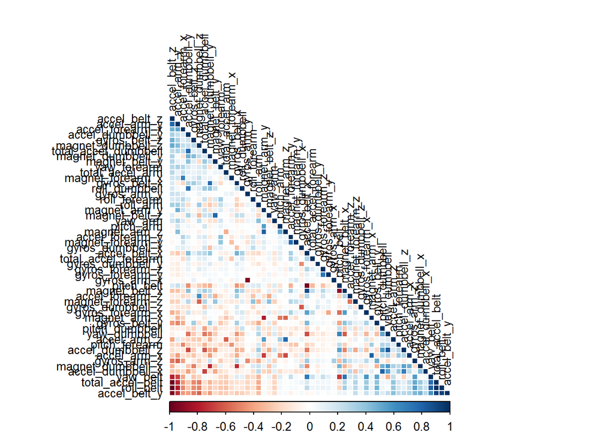

```r
correlations <- cor(training[, -53])
corrplot(correlations, order = "FPC", method = "color", type = "lower", tl.cex = 0.8,
    tl.col = rgb(0, 0, 0))
```

The image above shows in darker colors the pair of predictors that are highly correlated to each other(excluding the main diagonal). It looks like we might have many variables that can be groupped together in a weigthed combination.

Hence, my next step is to implement Principal Component Analysis to create new variables that summarize the ones identified above. Here careful is needed since the new variables might be difficult to explain.

## PCA

Using the caret package I preprocess the data leaving out the variable we want to predict (column 53). Then the predict function is used to apply the same PCA to the orignal data.

```r
preProc <- preProcess(training[, -53], method = "pca", thresh = 0.99)
PredTrain <- predict(preProc, training[, -53])
Predvalidation <- predict(preProc, validation[, -53])
```

## Fiting a Random Forest model

I chose to apply a Random Forest model using the caret package.